# UKBioBank data exploration - version 2.0

Nitay Alon

December 16, 2018

In this report we explore the Human Brain Data from UK-Bio Bank as a preliminary step of applying our mixture of sexes model and hypothesis testing. We begin with extraction of relevant data for our research, as described in the 15/11/2018 meeting summary and analysis of the data using EM algorithm.

# EDA

## Kolmogorov Smirnov test

Next we apply K-S test for each column to determine if the data is Log-Normally distributed. We begin with testing for normal distribution.

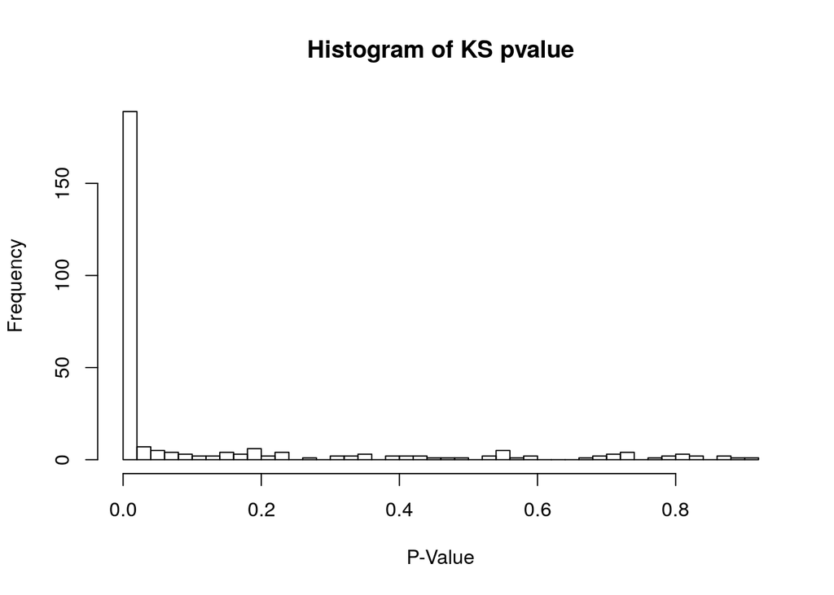

```r
hist(ks_results_log_normal_data$P_Value,
     breaks = 50,
     main = "Histogram of KS pvalue",
     xlab = "P-Value")
```

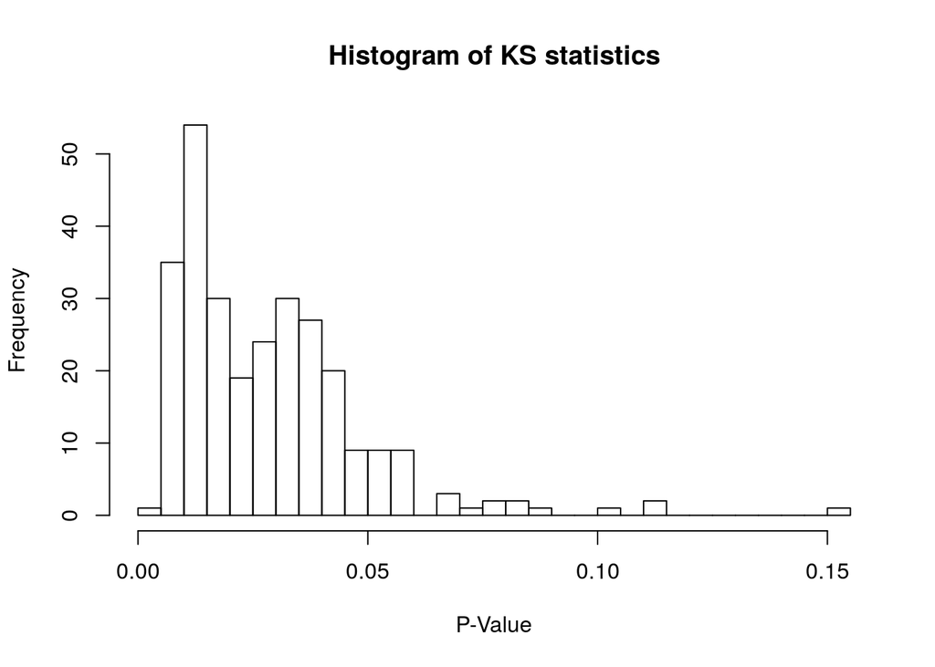

```r
hist(ks_results_log_normal_data$KS_Statistics,
     breaks = 50,
     main = "Histogram of KS statistics",
     xlab = "P-Value")
```

### KS test by gender

Moreover, the testing above assumes a single distribution model, while we assume mixture model, thus it might be beneficial to split the data according to the sex and apply KS test per gender data.

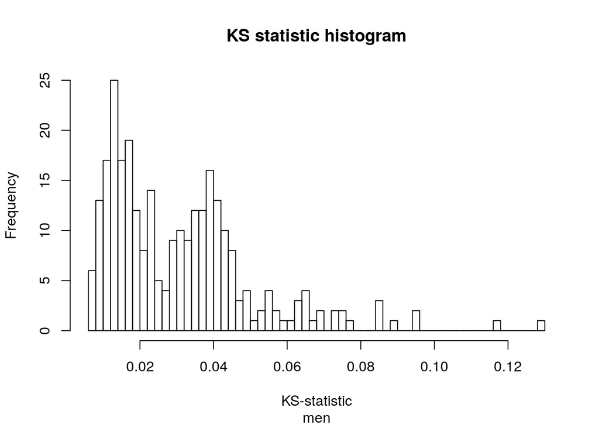

```r
hist(unlist(lapply(men_ks_test, function(x){x$statistic})),
     breaks = 50,
     main = "KS statistic histogram",sub = "men",
     xlab = "KS-statistic"
     )
```

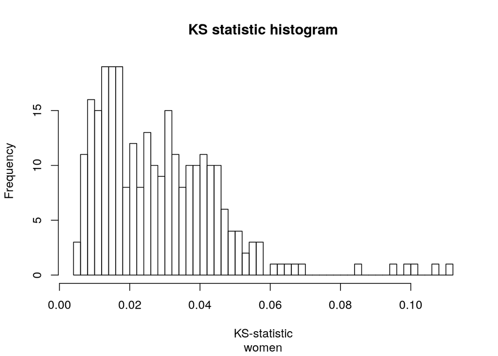

```r
hist(unlist(lapply(women_ks_test, function(x){x$statistic})),
     breaks = 50,
     main = "KS statistic histogram",sub = "women",
     xlab = "KS-statistic"
     )
```

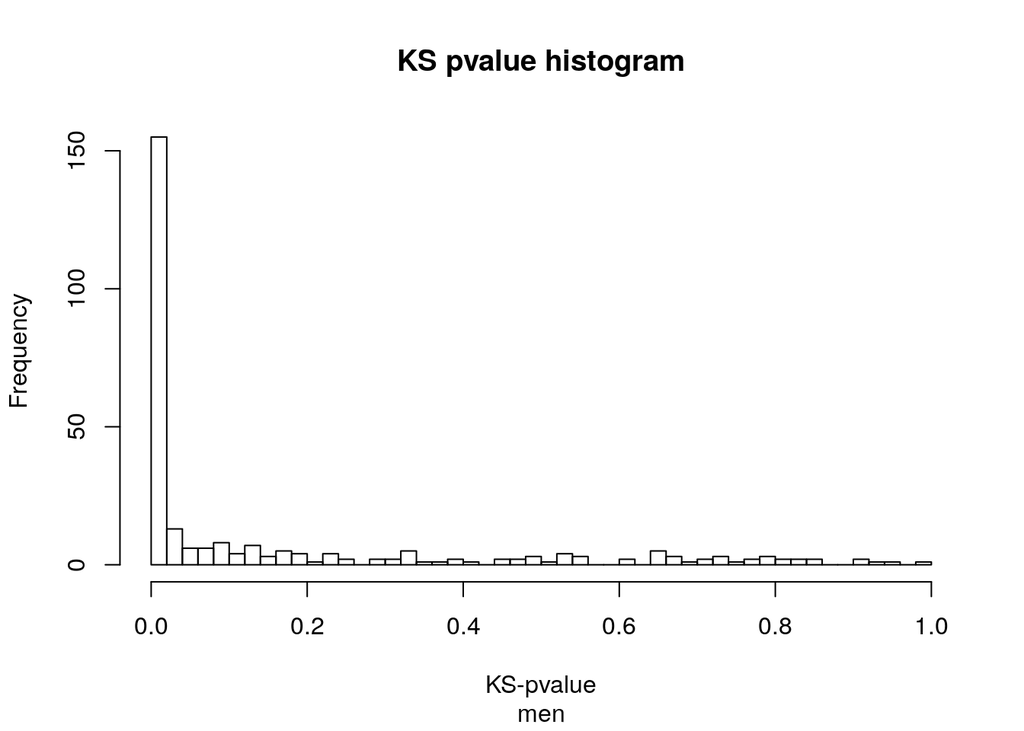

```r
hist(unlist(lapply(men_ks_test, function(x){x$p.value})),
     breaks = 50,
     main = "KS pvalue histogram",sub = "men",
     xlab = "KS-pvalue"
     )
```

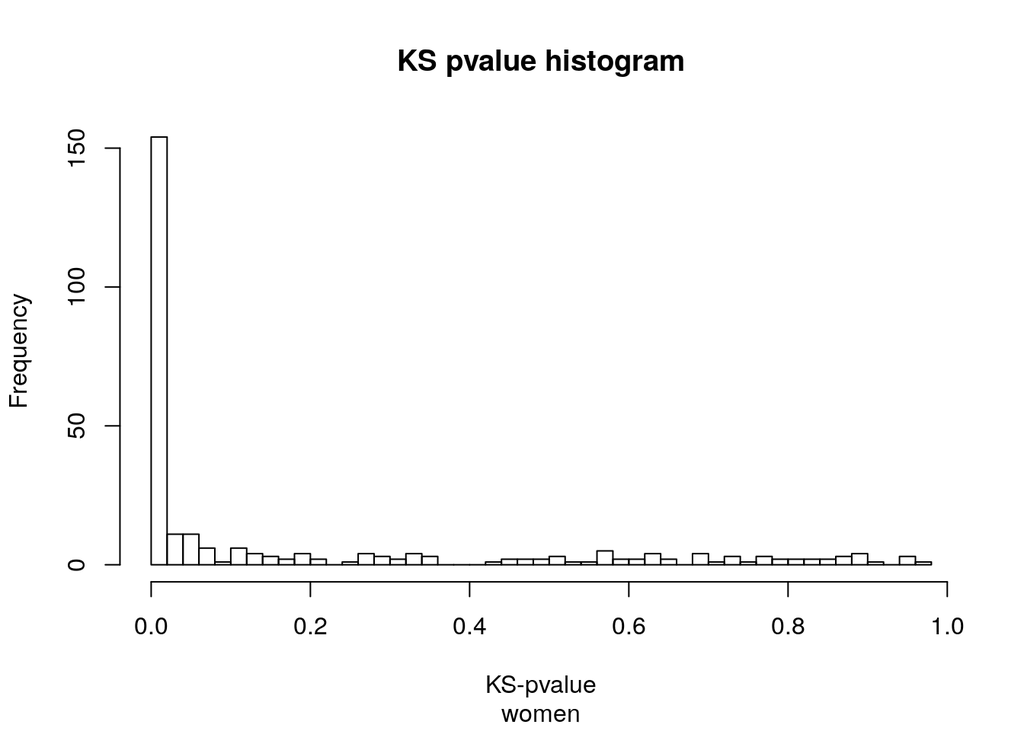

```r
hist(unlist(lapply(women_ks_test, function(x){x$p.value})),
     breaks = 50,
     main = "KS pvalue histogram",sub = "women",
     xlab = "KS-pvalue"
     )
```

looking at the last histogram it is clear that the null hypothesis is probably not true since the p-value doesn’t follow the expected uniform distribution.

## Validating the log-normal transformations

To validate the log transformation we examine if the third and froth moment of the logged data follow the expected behavior of the moments of normal distribution -
$$E(X^3) = 0 \\
E(X^4) = 3$$

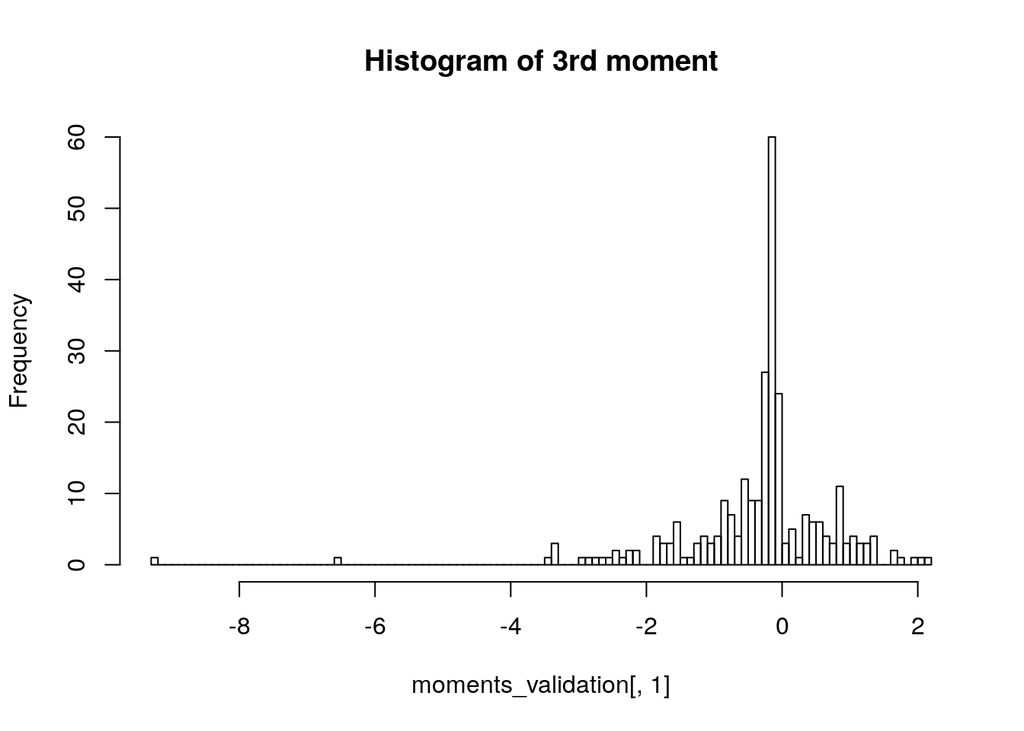

```r
data_for_log_and_scaled <- sapply(relevant_data, prepareDataForLogTransformation)
data_for_log_and_scaled %<>% data.frame()
logged_and_scaled <- sapply(data_for_log_and_scaled, function(x)
  {
  scale(log(x))
  })
logged_and_scaled %<>% data.frame()
moments_validation <- sapply(logged_and_scaled, validateMoments)
moments_validation %<>% t()

hist(moments_validation[,1],breaks = 100, main = "Histogram of 3rd moment")
```

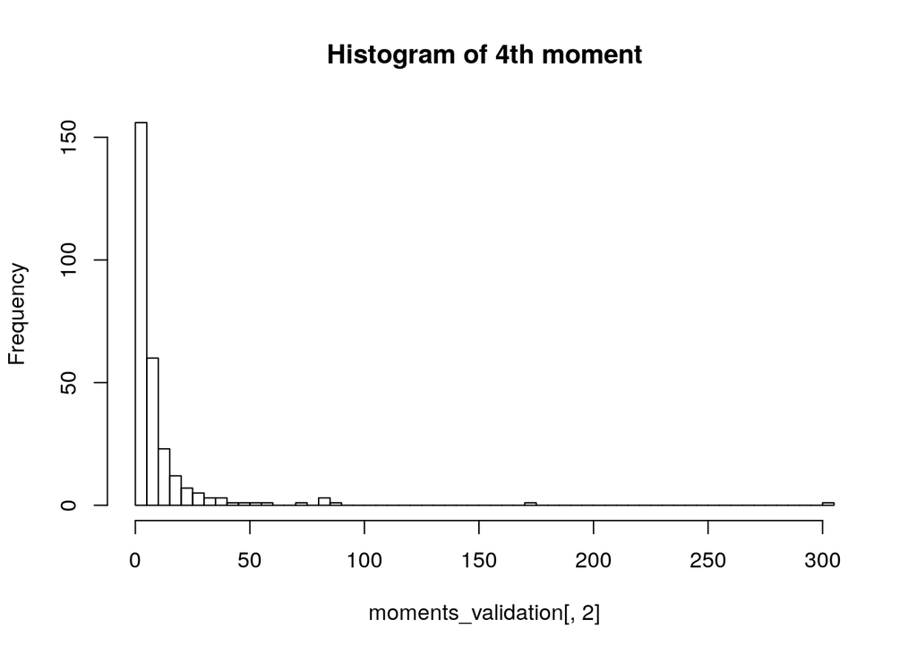

```r
hist(moments_validation[,2],breaks = 100, main = "Histogram of 4th moment")
```

```r
sd(moments_validation[,1])
```

```
## [1] 1.139428
```

```r
(4 / sqrt(sapply(data_for_log_and_scaled, length)))[1]
```

```
## X25056.2.0
## 0.02585438
```

Here we can see that some features do not follow the log-normal assumption. We can drill down and see some examples of features that violates our model:

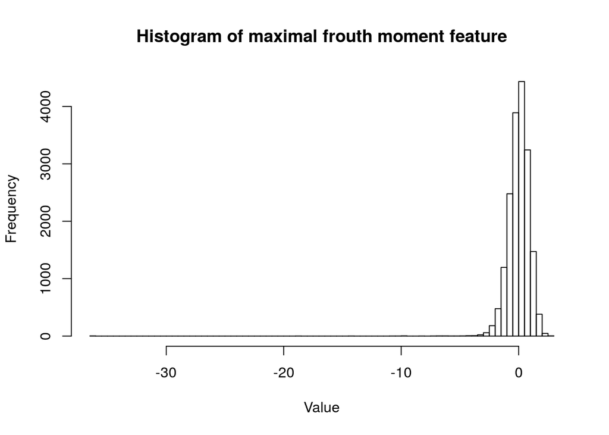

```r
extreme_feature_name_fourth_moment <- names(which.max(moments_validation[,2]))

extreme_feature_name_third_moment <- names(which.max(moments_validation[,1]))

hist(logged_and_scaled[extreme_feature_name_fourth_moment][,1]
     ,breaks = 100
     ,main = "Histogram of maximal frouth moment feature"
     ,xlab = "Value")
```

```r
summary(logged_and_scaled[extreme_feature_name_fourth_moment][,1])
```

```
##    Min. 1st Qu.  Median    Mean 3rd Qu.    Max.    NA's
## -36.191  -0.495   0.068   0.000   0.586   2.853    6009
```

```r
head(sort(logged_and_scaled[extreme_feature_name_fourth_moment][,1], decreasing = F),10)
```

```
##  [1] -36.191114 -36.191114 -36.191114 -18.654399 -14.457268 -10.612763
##  [7] -10.139373  -9.812449  -9.621518  -9.546031
```

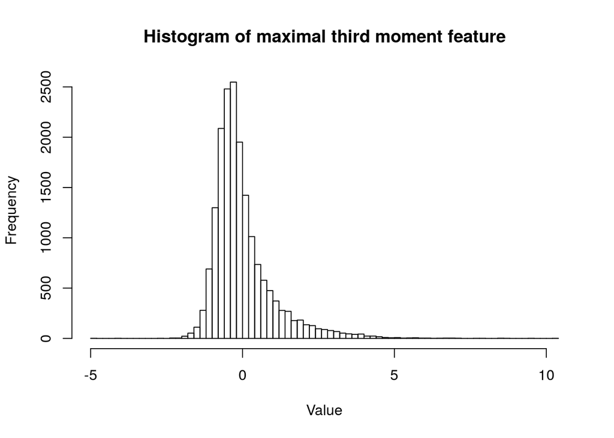

```r
hist(logged_and_scaled[extreme_feature_name_third_moment][,1]
  , breaks = 100
  ,main = "Histogram of maximal third moment feature"
  ,xlab = "Value")
```

```r
summary(logged_and_scaled[extreme_feature_name_third_moment][,1])
```

```
##    Min. 1st Qu.  Median    Mean 3rd Qu.    Max.    NA's
##  -4.853  -0.603  -0.243   0.000   0.287  10.257    6009
```

```r
quantile(logged_and_scaled[extreme_feature_name_third_moment][,1], 0.02, na.rm = T)
```

```
##        2%
## -1.274653
```

```r
sum(logged_and_scaled[extreme_feature_name_third_moment][,1] > 6, na.rm = T)
```

```
## [1] 21
```

```r
head(sort(logged_and_scaled[extreme_feature_name_third_moment][,1], decreasing = T),5)
```

```
## [1] 10.257077  9.515571  8.736322  8.535793  8.456704
```

```r
prop.table(table(full_relevant_data$Sex[logged_and_scaled[extreme_feature_name_third_moment][,1] >= 6]))
```

```
##
##         0         1
## 0.2857143 0.7142857
```

```r
prop.table(table(full_relevant_data$Sex))
```

```
##
##         0         1
## 0.5208055 0.4791945
```

here we see that in the first case the problem can be addressed by outlier removal but in the second case it is not the case.

### Deeper dive to skewed distribution analysis

We take a deeper look in the distributions that show high skewness:

```r
head(rownames(moments_validation)[order(moments_validation[,2],decreasing = T)],5)
```

```
## [1] "X25069.2.0" "X25068.2.0" "X25075.2.0" "X25077.2.0" "X25122.2.0"
```

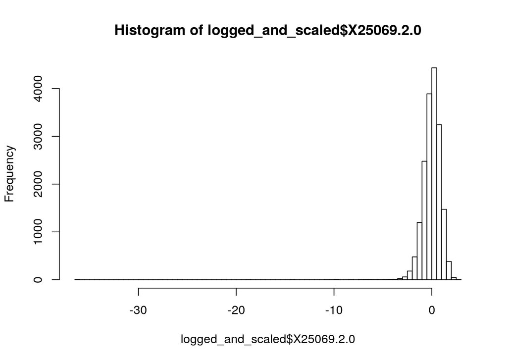

```r
hist(logged_and_scaled$X25069.2.0, breaks = 100)
```

```r
summary(logged_and_scaled$X25069.2.0)
```

```
##    Min. 1st Qu.  Median    Mean 3rd Qu.    Max.    NA's
## -36.191  -0.495   0.068   0.000   0.586   2.853    6009
```

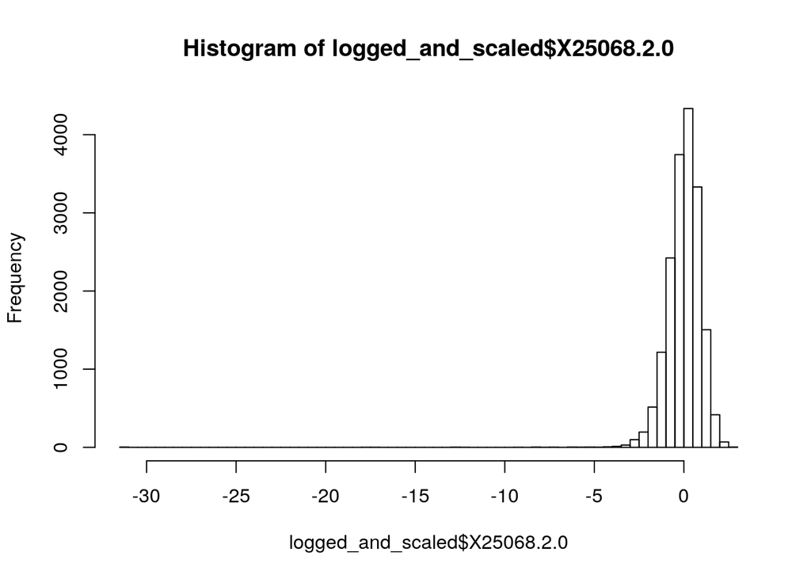

```r
hist(logged_and_scaled$X25068.2.0, breaks = 100)
```

```r
summary(logged_and_scaled$X25068.2.0)
```

```
##    Min. 1st Qu.  Median    Mean 3rd Qu.    Max.    NA's
## -31.029  -0.506   0.080   0.000   0.610   2.703    6009
```

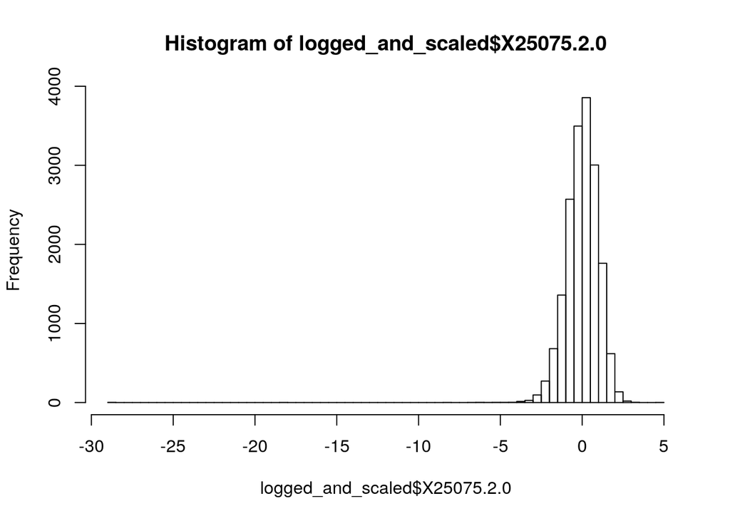

```r
hist(logged_and_scaled$X25075.2.0, breaks = 100)
```

```r
summary(logged_and_scaled$X25075.2.0)
```

```
##    Min. 1st Qu.  Median    Mean 3rd Qu.    Max.    NA's
## -28.879  -0.593   0.059   0.000   0.655   4.799    6009
```

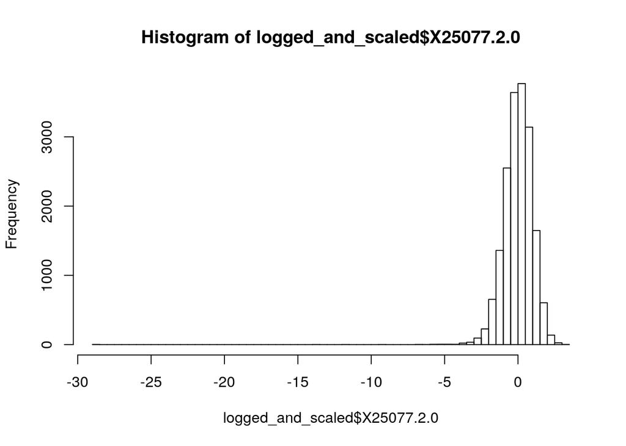

```r
hist(logged_and_scaled$X25077.2.0, breaks = 100)
```

```r
summary(logged_and_scaled$X25077.2.0)
```

```
##    Min. 1st Qu.  Median    Mean 3rd Qu.    Max.    NA's
## -28.921  -0.576   0.045   0.000   0.649   3.397    6009
```

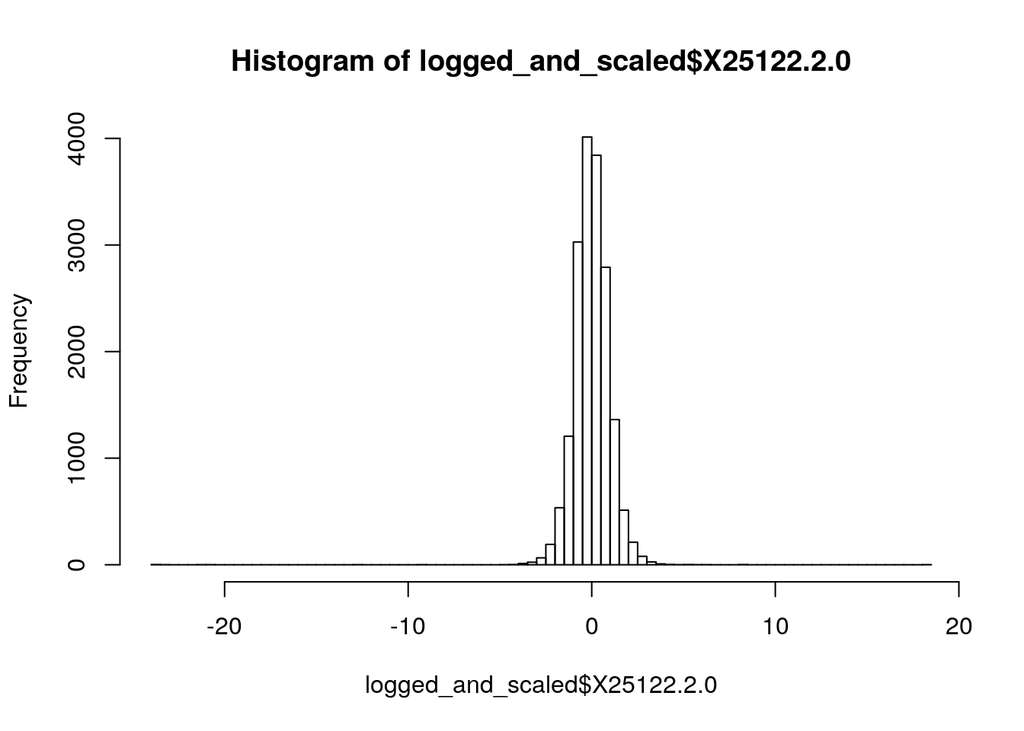

```r
hist(logged_and_scaled$X25122.2.0, breaks = 100)
```

```r
summary(logged_and_scaled$X25122.2.0)
```

```
##    Min. 1st Qu.  Median    Mean 3rd Qu.    Max.    NA's
## -23.567  -0.548  -0.016   0.000   0.550  18.424    6009
```

```r
head(rownames(moments_validation)[order(moments_validation[,1],decreasing = T)],5)
```

```
## [1] "X25147.2.0" "X25146.2.0" "X25115.2.0" "X25131.2.0" "X25130.2.0"
```

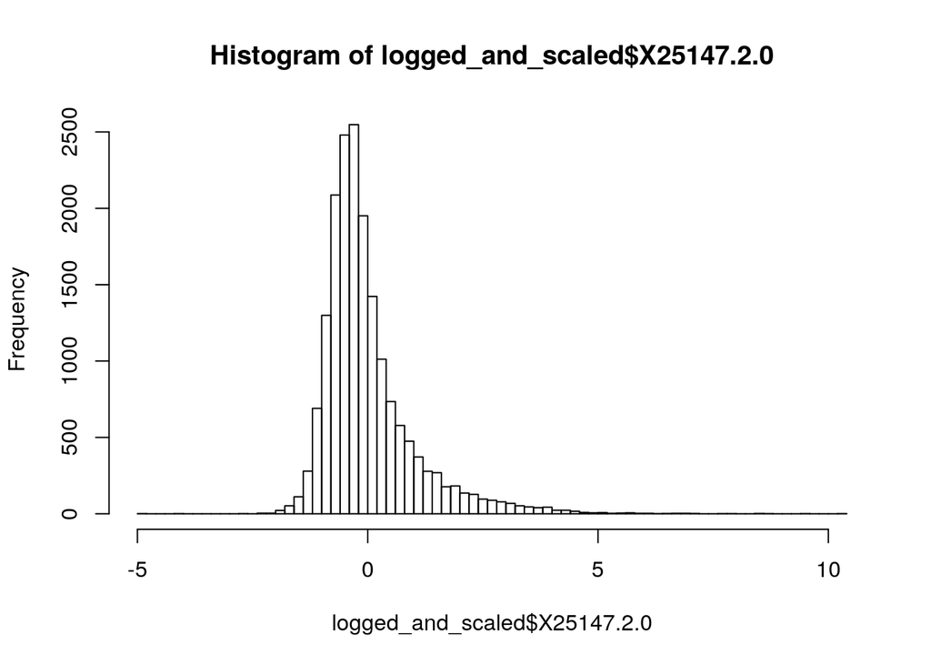

```r
hist(logged_and_scaled$X25147.2.0, breaks = 100)
```

```r
summary(logged_and_scaled$X25147.2.0)
```

```
##    Min. 1st Qu.  Median    Mean 3rd Qu.    Max.    NA's
##  -4.853  -0.603  -0.243   0.000   0.287  10.257    6009
```

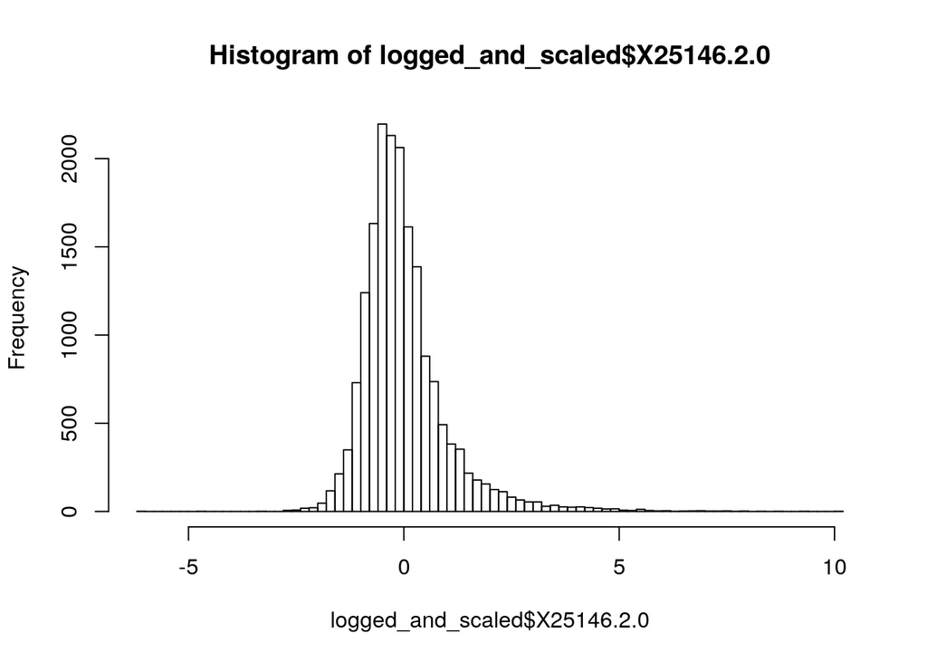

```r
hist(logged_and_scaled$X25146.2.0, breaks = 100)
```

```r
summary(logged_and_scaled$X25146.2.0)
```

```
##    Min. 1st Qu.  Median    Mean 3rd Qu.    Max.    NA's
##  -6.129  -0.591  -0.180   0.000   0.347  10.033    6009
```

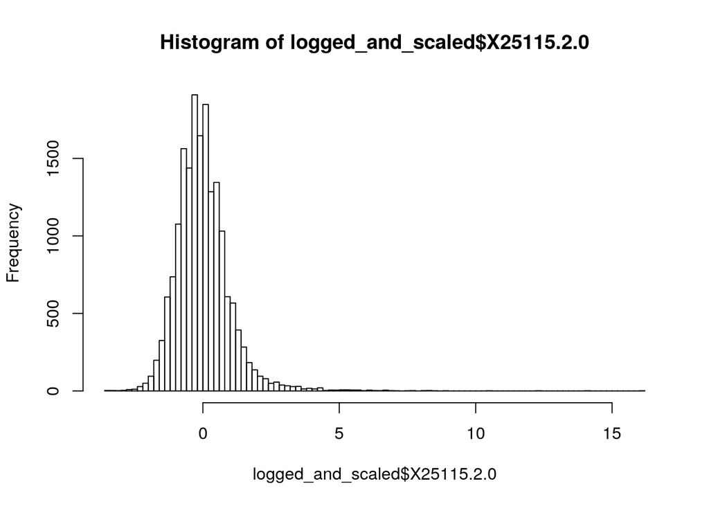

```r
hist(logged_and_scaled$X25115.2.0, breaks = 100)
```

```r
summary(logged_and_scaled$X25115.2.0)
```

```
##    Min. 1st Qu.  Median    Mean 3rd Qu.    Max.    NA's
##  -3.575  -0.611  -0.099   0.000   0.474  16.043    6009
```

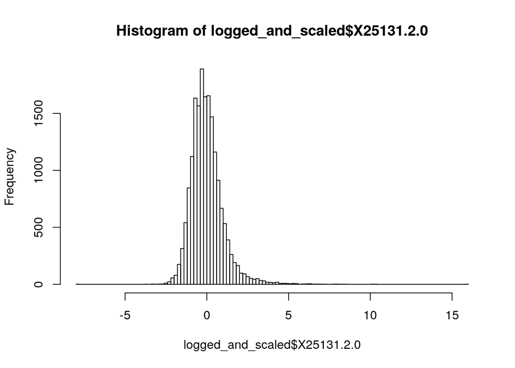

```r
hist(logged_and_scaled$X25131.2.0, breaks = 100)
```

```r
summary(logged_and_scaled$X25131.2.0)
```

```
##    Min. 1st Qu.  Median    Mean 3rd Qu.    Max.    NA's
##  -7.887  -0.626  -0.120   0.000   0.470  15.943    6009
```

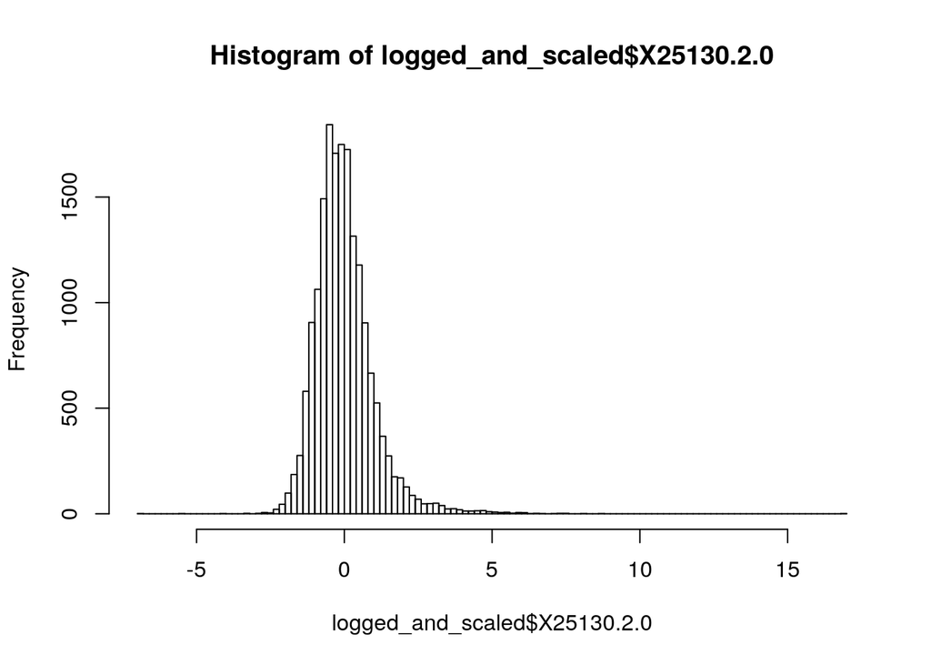

```r
hist(logged_and_scaled$X25130.2.0, breaks = 100)
```

```r
summary(logged_and_scaled$X25130.2.0)
```

```
##    Min. 1st Qu.  Median    Mean 3rd Qu.    Max.    NA's
##  -7.000  -0.638  -0.110   0.000   0.457  16.922    6009
```

Summing the results of the above analysis we’ve decided to trim the logged data using the following trimming schema: 1. Any value outside the interval $(-5,10)$ is winzorised. 2. If the minimum higher than -5 but the 2nd minimal is higher (say -4, -2.8) we trim the minimum. 3. The upper tail is trimmed only at 10

## Composite vs simple hypothesis testing

First we test the single distribution vs composite distribution hypotheses:
$$H_0:f_X(x) = f_X(x) \\
H_1:f_X(x) = pf_X(x) + (1-p)g_X(x)$$

hypothesis testing:

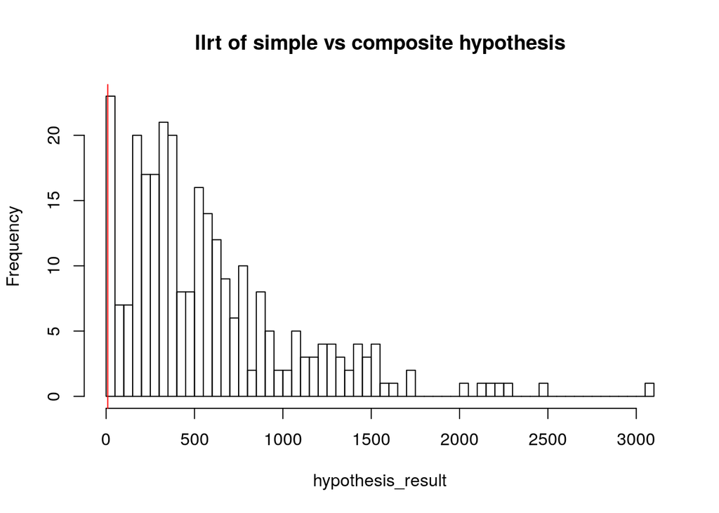

```r
hist(hypothesis_result, breaks = 70, main = "llrt of simple vs composite hypothesis")
abline(v = qexp(0.99,0.5), col = "red")
```

```r
mean(hypothesis_result > qexp(0.99,0.5))
```

```
## [1] 0.9571429
```

for 96% of the features we reject the null hypothesis.

Next we plot a histogram for the features that we haven’t rejected the null hypothesis for. The goal is to try and characterize them:

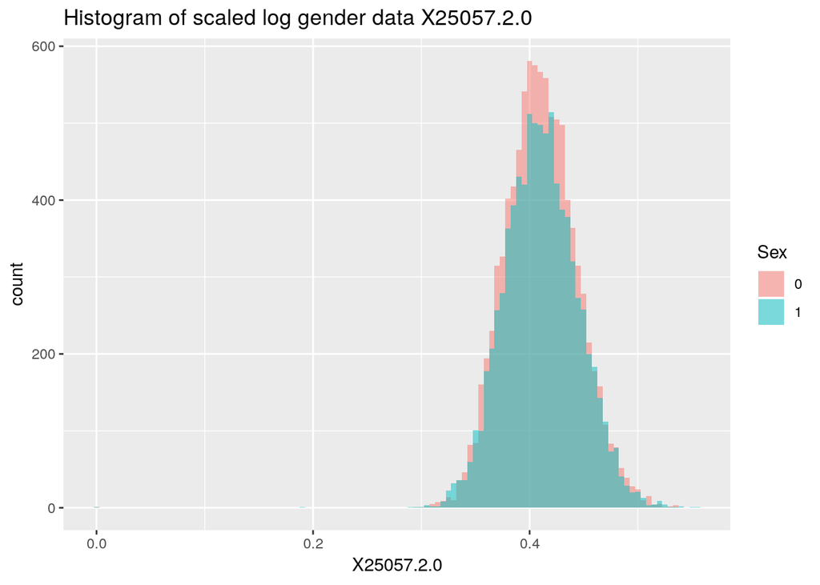

```r
not_rejecting_the_null_hypothesis <- names(which(hypothesis_result < qchisq(0.99,2)))

i <- 1

df <- data.frame(feature = full_relevant_data[not_rejecting_the_null_hypothesis[i]],
                 "Sex" = full_relevant_data$Sex)
bioBankHistogramBySex(df,not_rejecting_the_null_hypothesis[i])
```

```r
names(df) = c("Feature","Sex")
df %>%
  group_by(Sex) %>%
  filter(!is.na(Feature)) %>%
  summarise(average = mean(Feature), minimun = min(Feature), maximum = max(Feature), std = sd(Feature))
```

```
## # A tibble: 2 x 5
##     Sex average minimun maximum    std
##   <int>   <dbl>   <dbl>   <dbl>  <dbl>
## 1     0   0.411       0   0.536 0.0334
## 2     1   0.411       0   0.556 0.0340
```

### Summarizng the first hypothesis test

In order to decide for which features we reject the null hypothesis we compare the $llrt$ with the critical value of the proper $\chi^2$ statistic. Using Wald’s theorem we know that under the null hypothesis the llrt is distributed $\chi^2$ with $4-2$ df (We have 2 parameters in the null hypothesis and 4 in the alternative). The red line in the above histogram indicate the location of the rejecting limit. Moreover an inspection of the non rejected features indicate that those features have low within variance. This analysis is presented in the following histogram:

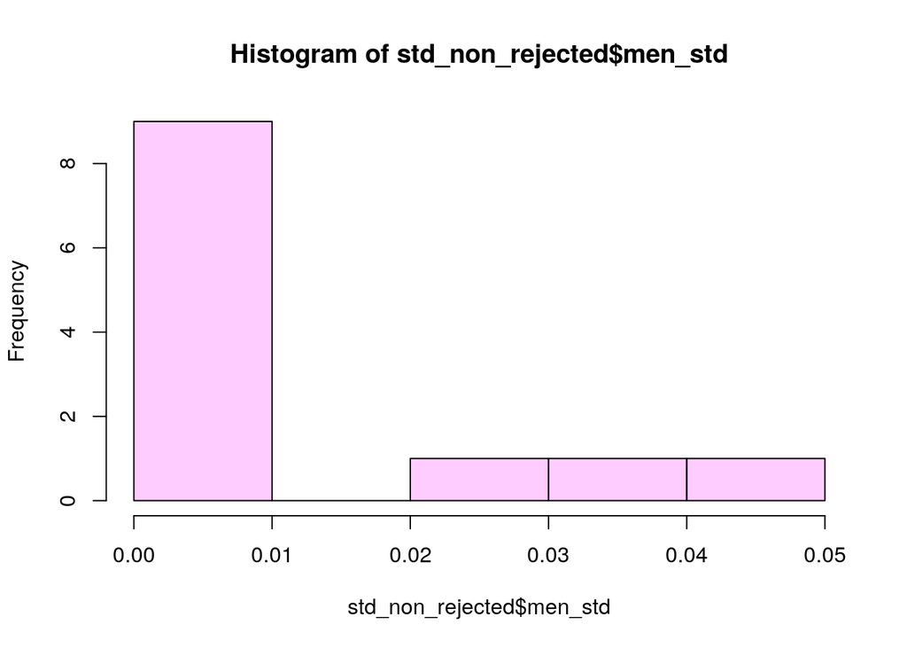

```r
std_non_rejected <- computingStandardDeviationWithInGroups(not_rejecting_the_null_hypothesis)
hist(std_non_rejected$men_std,breaks = 5, col = rgb(1,0,1,alpha = 0.2))
```

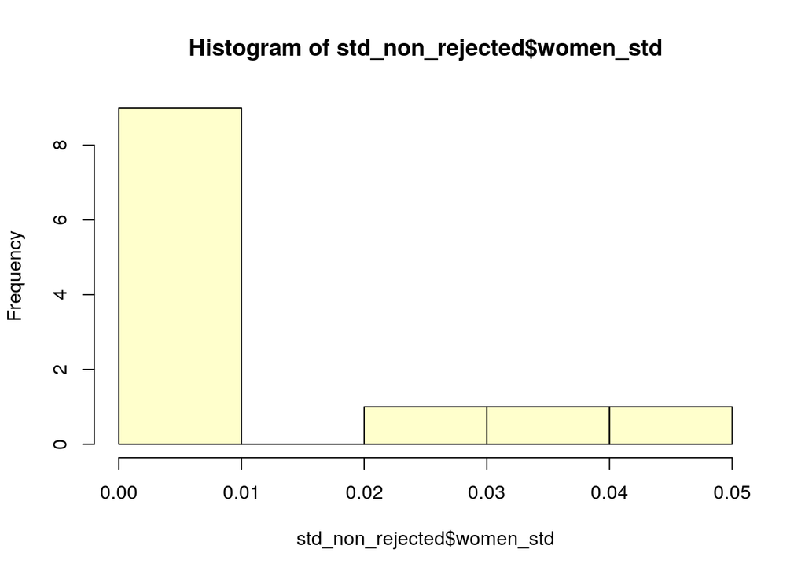

```r
hist(std_non_rejected$women_std,breaks = 5, col = rgb(1,1,0,alpha = 0.2))
```

# Mixture model - pure type vs Mixture of Mixtures

Our main focus is on testing our mixture of mixture model, to test these hypotheses we apply the composite hypothesis log-likelihood ratio test.

## Log normal assumption

We start with assuming log-normal model

Now, We plot the llrt results:

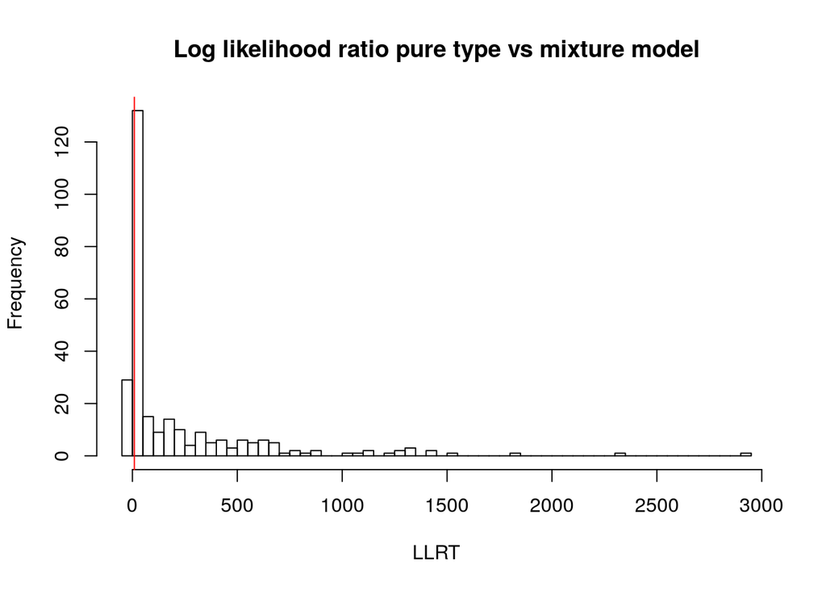

```r
composite_hypothesis_result_llrt <-
  unlist(lapply(composite_hypothesis_result, function(x){x$llrt}))
hist(composite_hypothesis_result_llrt, breaks = 50,
     main = "Log likelihood ratio pure type vs mixture model",
     xlab = "LLRT")
abline(v = qexp(0.99,0.5), col = "red")
```

(red line indicating the $99\%$ percentile of $exp(\frac{1}{2})$).

### Analyzing low llrt

We see that some features have llrt less than 1 - let’s review them separately.

```r
X25098.2.0 <- na.omit(relevant_data$X25098.2.0)
X25098.2.0[X25098.2.0 > 0] %>%
  logNormalDataPreparation %>%
  summary()
```

```
##        V1
##  Min.   :-5.09812
##  1st Qu.:-0.58472
##  Median : 0.05649
##  Mean   : 0.00000
##  3rd Qu.: 0.66845
##  Max.   : 3.25204
```

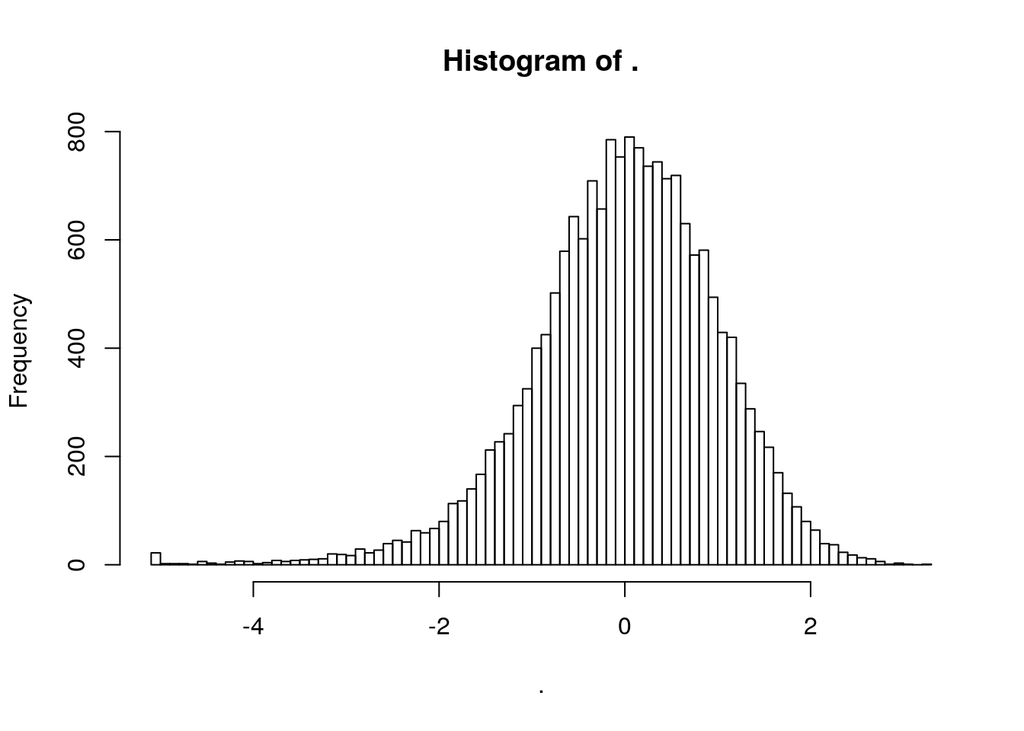

```r
X25098.2.0[X25098.2.0 > 0] %>%
  logNormalDataPreparation %>%
  hist(., breaks = 100)
```

```r
pureTypeMixtureVsCompositeMixture(X25098.2.0,
full_relevant_data$Sex,"L")
```

```
## [1] -0.001671686
```

Checking the lowest llrt features:

```r
low_llrt_features <- composite_hypothesis_result_llrt[
  composite_hypothesis_result_llrt$feature_id %in% list_of_zero_llrt_features_pure_type_vs_mix_model,]
```

Selecting the lowest llrt feature

Plotting the distribution:

```r
X25799.2.0  <- na.omit(relevant_data$X25799.2.0)
X25799.2.0 %>%
  prepareDataForLogTransformation() %>%
  log() %>%
  summary()
```

```
##    Min. 1st Qu.  Median    Mean 3rd Qu.    Max.
##   5.511   7.136   7.277   7.274   7.417   8.156
```

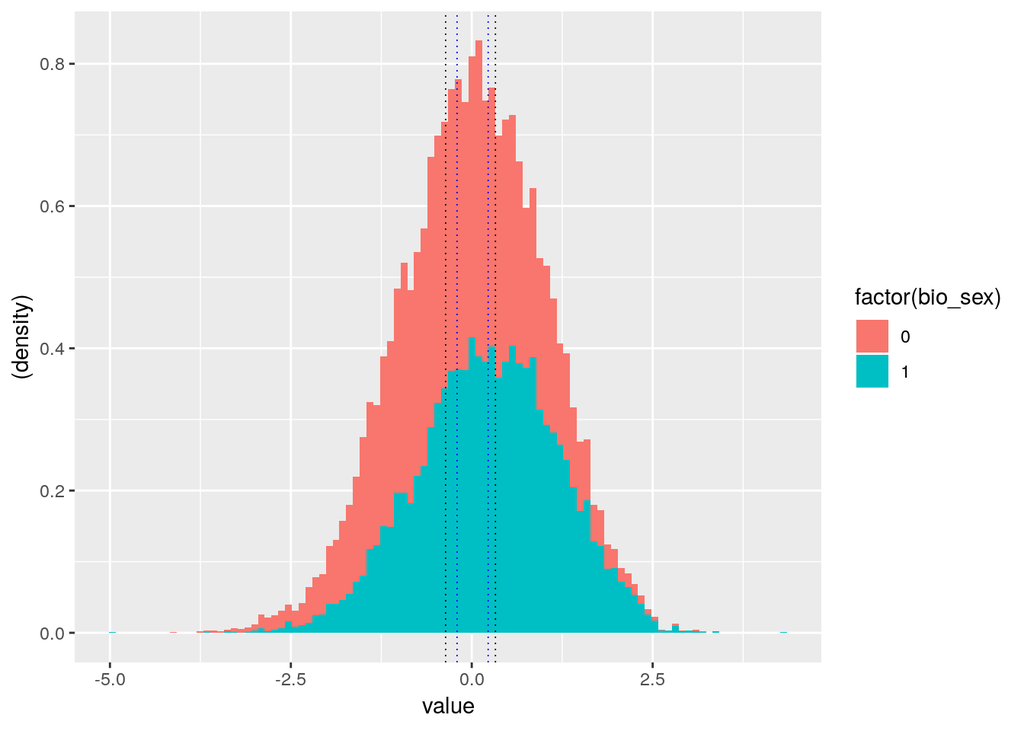

```r
gender_data_for_X25799.2.0 <-
  full_relevant_data$Sex[!is.na(relevant_data$X25799.2.0)]

data_for_ggplot_X25799.2.0 = data.frame(value = X25799.2.0 %>%
  logNormalDataPreparation()
  ,bio_sex = gender_data_for_X25799.2.0)
ggplot(data_for_ggplot_X25799.2.0, aes(value, fill = factor(bio_sex))) +
  geom_histogram(bins = 100, aes(y = (..density..))) +
  geom_vline(xintercept = c(composite_hypothesis_less_than_zero_llrt_em[[minimal_llrt_feature]]$null_hypothesis$men_mean, composite_hypothesis_less_than_zero_llrt_em[[minimal_llrt_feature]]$null_hypothesis$women_mean),linetype="dotted",
                color = "blue", size=0.3) +
  geom_vline(xintercept = c(composite_hypothesis_less_than_zero_llrt_em[[minimal_llrt_feature]]$alternative_hypothesis$m_parameters$mu_1, composite_hypothesis_less_than_zero_llrt_em[[minimal_llrt_feature]]$alternative_hypothesis$m_parameters$mu_2),linetype="dotted",
                color = "black", size=0.3)
```

The vertical lines indicate the location of the null hypothesis and alternative gender means (blue and black respectively).

### Analysis of composite hypothesis testing:

In order to determine the number of significant features we use Wald’s theorem again this time with $\chi^2_2$ distribution.

```r
critical_value <- qexp(0.99,1/2)

composite_hypothesis_result_llrt$reject_the_null_hypothesis <-
  composite_hypothesis_result_llrt$llrt > critical_value

composite_hypothesis_result_llrt$reject_the_null_hypothesis %>%
  table() %>%
  prop.table()
```

```
## .
##     FALSE      TRUE
## 0.3928571 0.6071429
```

So, for the small majority of the features we reject the null hypothesis.

#### Distribution of the p-value

One aspect of analysis is the distribution of the $p-value$. If it doesn’t follow a uniform distribution is may imply that the null hypothesis isn’t true.

```r
ifelse(composite_hypothesis_result_llrt$llrt < 0,
       0 , composite_hypothesis_result_llrt$llrt)
```

[output not shown]

[output cut: 41 more lines]

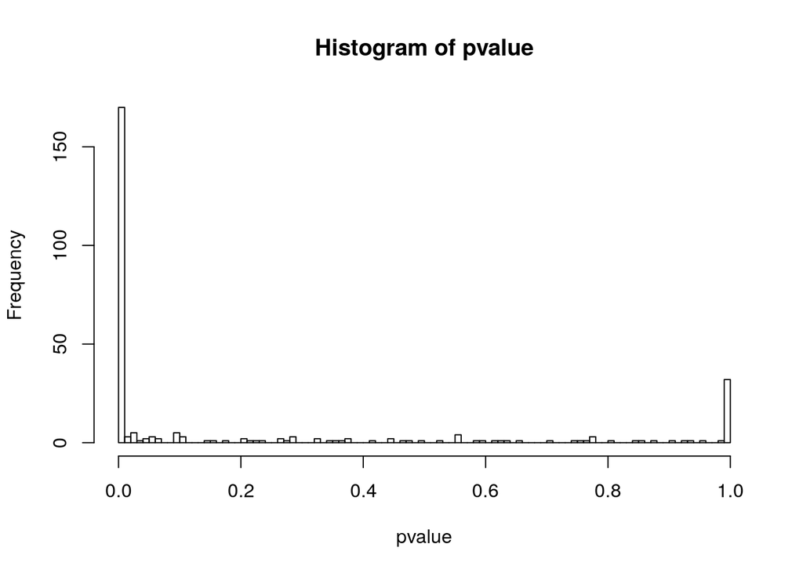

```r
pvalue <- 1 - pchisq(ifelse(composite_hypothesis_result_llrt$llrt < 0, 0 , composite_hypothesis_result_llrt$llrt),2)
hist(pvalue, breaks = 100)
```

The distribution follows a U shape. If we plot the features and their corresponding p-value:

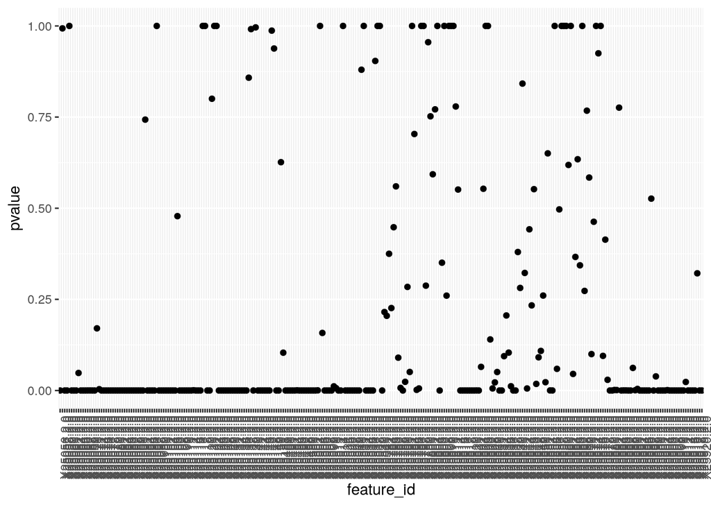

```r
composite_hypothesis_result_llrt$pvalue <- 1 - pchisq(ifelse(composite_hypothesis_result_llrt$llrt < 0, 0 , composite_hypothesis_result_llrt$llrt),2)
ggplot(composite_hypothesis_result_llrt, aes(feature_id, pvalue)) +
  geom_point() +
  theme(axis.text.x = element_text(angle = 90, hjust = 1))
```

While it’s hard to read the features names we can see some pattern in the distribution of the p-value which might indicate that some regions of the brain are pure masculine-feminine and some are mixture of the two.